# Does cheaper housing make life more expensive?

Rent, commuting and winter bills in Yerevan

DS116 Data Visualization · data from November 2026

Someone works in the centre of Yerevan. Should they rent in Kentron, or in a cheaper district and commute by bus, by car or by Yandex Taxi? We compare real asking rents with modeled commuting costs and winter bills. Each section asks one question, shows one chart and gives a short answer.

## The data and our assumptions

```r
library(ggplot2)
library(dplyr)

# White chart background for every chart
theme_set(theme_bw())

rentals <- read.csv("data/rentals.csv")
tariffs <- read.csv("data/tariffs.csv")
wages   <- read.csv("data/wages.csv")
taxi    <- read.csv("data/taxi_tariffs.csv")
traffic <- read.csv("data/traffic_score_weekday.csv")

# Look up one tariff value by its name
rate <- function(name) tariffs$value[tariffs$parameter == name]

# Household: one person commutes to the centre on 22 days a month
days      <- 22
commuters <- 1

# Value of time: half of the 2025 average gross hourly wage
wage       <- wages$Value[wages$Year == 2025]
hourly     <- wage / (22 * 8)
time_value <- hourly / 2

# Winter bills, the same in every district (heating is the gas)
utilities <- 150 * rate("electric_day_low") +
  50 * rate("electric_night_low") +
  100 * rate("gas_per_1000m3") / 1000 +
  8 * rate("water_per_m3")

# Traffic: each Yandex traffic point above 2 adds 13% to the empty-road time
k <- 0.13
score_morning <- traffic$yandex_score[traffic$time == "08:45"]
score_evening <- traffic$yandex_score[traffic$time == "18:30"]

# Taxi: minutes spent waiting for the car on each trip
taxi_wait <- 3

# Yandex fare for one trip, from the rules on the Yandex Yerevan fare page:
# minimum price (covers 1 km and 2.5 min) + price per km + price per minute,
# times any surge, rounded up to the next 100 AMD
taxi_fare <- function(km, minutes, class, surge = 1) {
  t <- taxi[match(class, taxi$service_class), ]
  price <- t$minimum_price_amd +
    t$city_amd_per_km * pmax(km - 1, 0) +
    t$city_amd_per_min * pmax(minutes - 2.5, 0)
  ceiling(surge * price / 100) * 100
}
```

`rentals.csv` has 276 advertisements for two-room, furnished apartments of 45–75 m² from one agency (WSE.AM), collected on 5 November 2026. Each row also has the road distance and empty-road driving time to Republic Square and back. The taxi prices are Yandex’s official Yerevan rates, and the traffic score is Yandex’s 0–10 rating of how busy the city’s roads are.

## Where is rent cheaper?

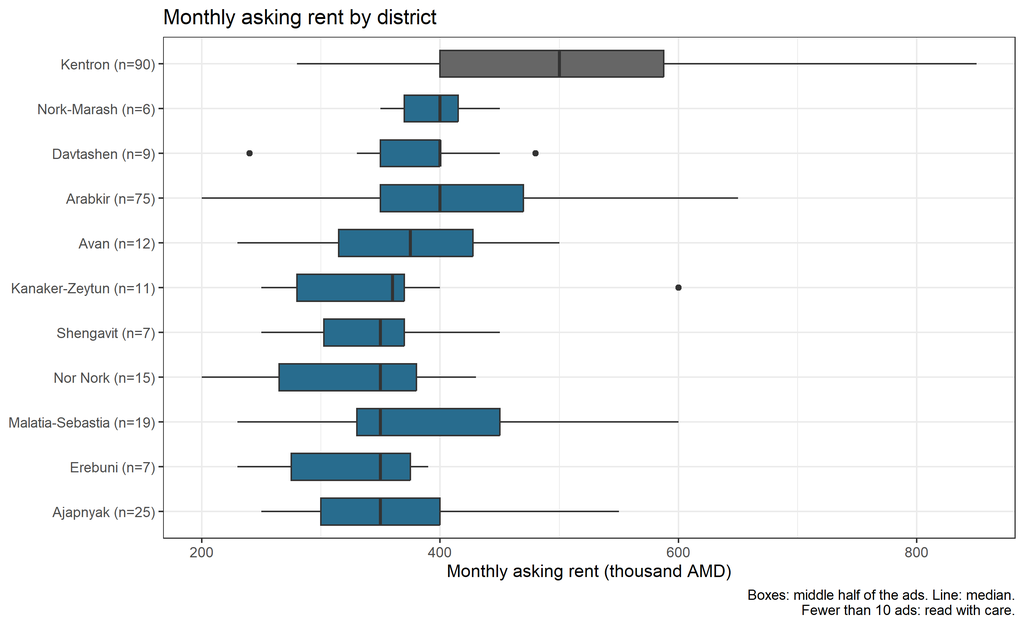

```r
# One summary row per district
districts <- rentals %>%
  group_by(district) %>%
  summarise(n = n(),
            rent = median(rent_amd),
            km = median(round_trip_km),
            minutes = median(freeflow_minutes))

rent_kentron <- districts$rent[districts$district == "Kentron"]

# Districts ordered from cheapest to most expensive median rent
district_order <- districts$district[order(districts$rent)]

# Axis labels with the number of ads
districts$label <- paste0(districts$district, " (n=", districts$n, ")")
label_order <- districts$label[order(districts$rent)]
rentals <- left_join(rentals, districts[c("district", "label")], by = "district")

ggplot(rentals, aes(x = factor(label, levels = label_order),
                    y = rent_amd / 1000,
                    fill = district == "Kentron")) +
  geom_boxplot(width = 0.6) +
  coord_flip() +
  scale_fill_manual(values = c("FALSE" = "#286C8E", "TRUE" = "grey40"),
                    guide = "none") +
  labs(title = "Monthly asking rent by district",
       x = NULL,
       y = "Monthly asking rent (thousand AMD)",
       caption = paste("Boxes: middle half of the ads. Line: median.",
                       "Fewer than 10 ads: read with care.",
                       sep = "\n"))
```

**Answer.** Kentron has the highest median rent: 500,000 AMD a month. Other districts range from 350,000 to 400,000 AMD. The boxes overlap, so the district alone does not decide a flat’s price.

## How does traffic change the trip during the day?

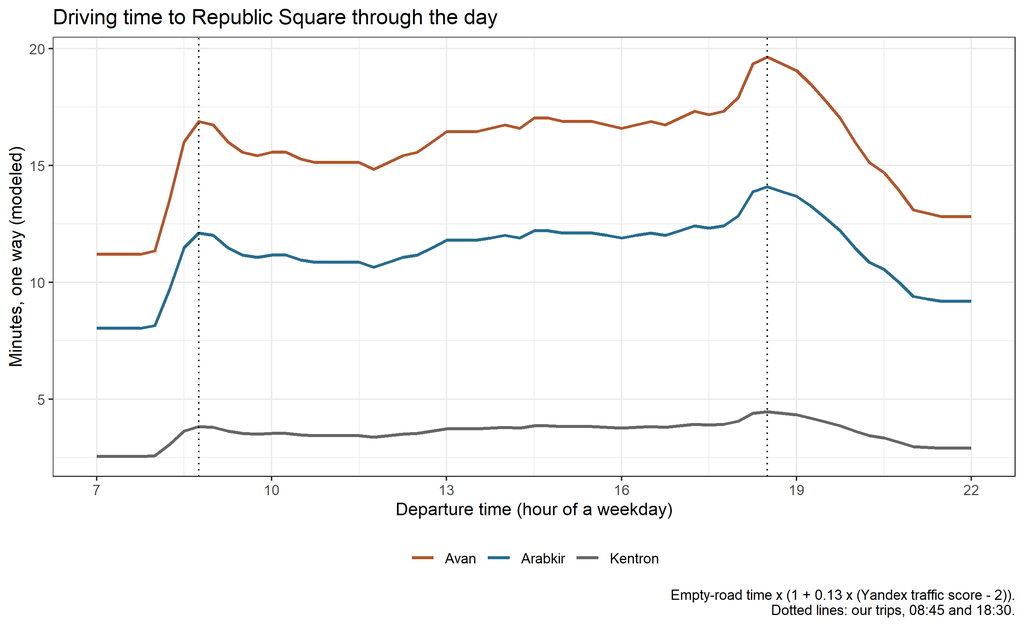

```r
# Turn "08:45" into 8.75 hours for the x-axis
traffic$hour <- as.numeric(substr(traffic$time, 1, 2)) +
  as.numeric(substr(traffic$time, 4, 5)) / 60

# Road minutes to the centre at every time of day, for three districts
by_hour <- expand.grid(time = traffic$time,
                       district = c("Kentron", "Arabkir", "Avan"),
                       stringsAsFactors = FALSE) %>%
  left_join(traffic, by = "time") %>%
  left_join(districts, by = "district") %>%
  mutate(road_minutes = minutes / 2 * (1 + k * (yandex_score - 2)))

by_hour$district <- factor(by_hour$district,
                           levels = c("Avan", "Arabkir", "Kentron"))

ggplot(by_hour, aes(x = hour, y = road_minutes, color = district)) +
  geom_line(linewidth = 1) +
  geom_vline(xintercept = c(8.75, 18.5), linetype = "dotted") +
  scale_x_continuous(breaks = seq(7, 22, by = 3)) +
  scale_color_manual(values = c("Kentron" = "grey40",
                                "Arabkir" = "#286C8E",
                                "Avan" = "#AF572E")) +
  labs(title = "Driving time to Republic Square through the day",
       x = "Departure time (hour of a weekday)",
       y = "Minutes, one way (modeled)",
       color = NULL,
       caption = paste("Empty-road time x (1 + 0.13 x (Yandex traffic score - 2)).",
                       "Dotted lines: our trips, 08:45 and 18:30.",
                       sep = "\n")) +
  theme(legend.position = "bottom")
```

**Answer.** In this model, traffic stretches every trip, most at 18:30. A trip from Avan takes 11.2 minutes at 07:00 and 19.7 minutes at 18:30. Far districts lose more minutes because the model stretches each trip by the same percentage. The scores were read from Yandex’s February 2020 weekday chart.

## How long is the commute?

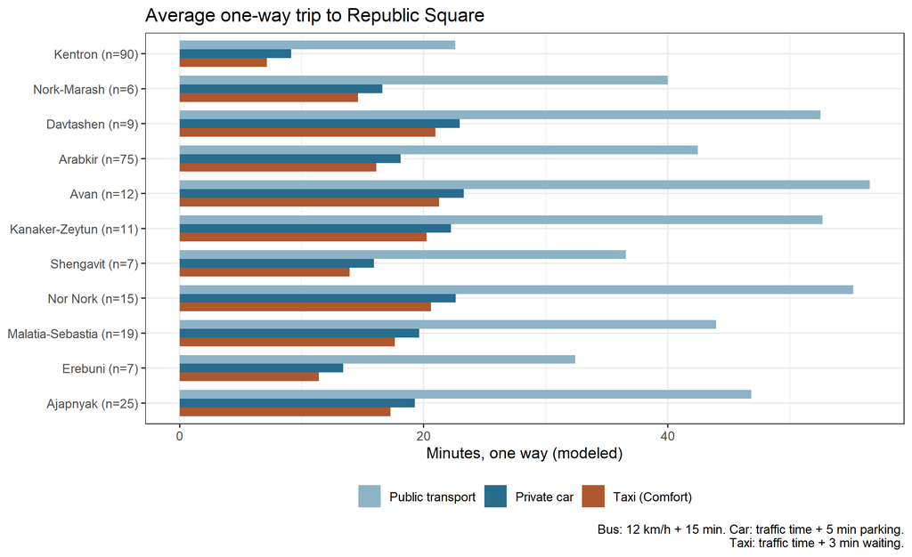

```r
# Road minutes in the morning rush and the evening rush
districts <- districts %>%
  mutate(road_in = minutes / 2 * (1 + k * (score_morning - 2)),
         road_out = minutes / 2 * (1 + k * (score_evening - 2)))

# Round-trip minutes for each way of travelling
public <- districts %>%
  mutate(mode = "Public transport",
         trip_minutes = km / 12 * 60 + 30)

car <- districts %>%
  mutate(mode = "Private car",
         trip_minutes = road_in + road_out + 10)

taxi_trips <- districts %>%
  mutate(mode = "Taxi (Comfort)",
         trip_minutes = road_in + road_out + 2 * taxi_wait)

travel <- rbind(public, car, taxi_trips)

mode_colors <- c("Public transport" = "#8DB3C7",
                 "Private car" = "#286C8E",
                 "Taxi (Comfort)" = "#AF572E")
mode_order <- names(mode_colors)

ggplot(travel, aes(x = factor(label, levels = label_order),
                   y = trip_minutes / 2,
                   fill = factor(mode, levels = rev(mode_order)))) +
  geom_col(position = "dodge", width = 0.75) +
  coord_flip() +
  scale_fill_manual(values = mode_colors, breaks = mode_order) +
  labs(title = "Average one-way trip to Republic Square",
       x = NULL,
       y = "Minutes, one way (modeled)",
       fill = NULL,
       caption = paste("Bus: 12 km/h + 15 min. Car: traffic time + 5 min parking.",
                       "Taxi: traffic time + 3 min waiting.",
                       sep = "\n")) +
  theme(legend.position = "bottom")
```

**Answer.** The bus is the slowest way from every district. Car and taxi use the same roads, so they take almost the same time. Bus time does not use the traffic score: its 12 km/h is assumed to include traffic already. These are modeled times, not timed journeys.

## What does a month cost?

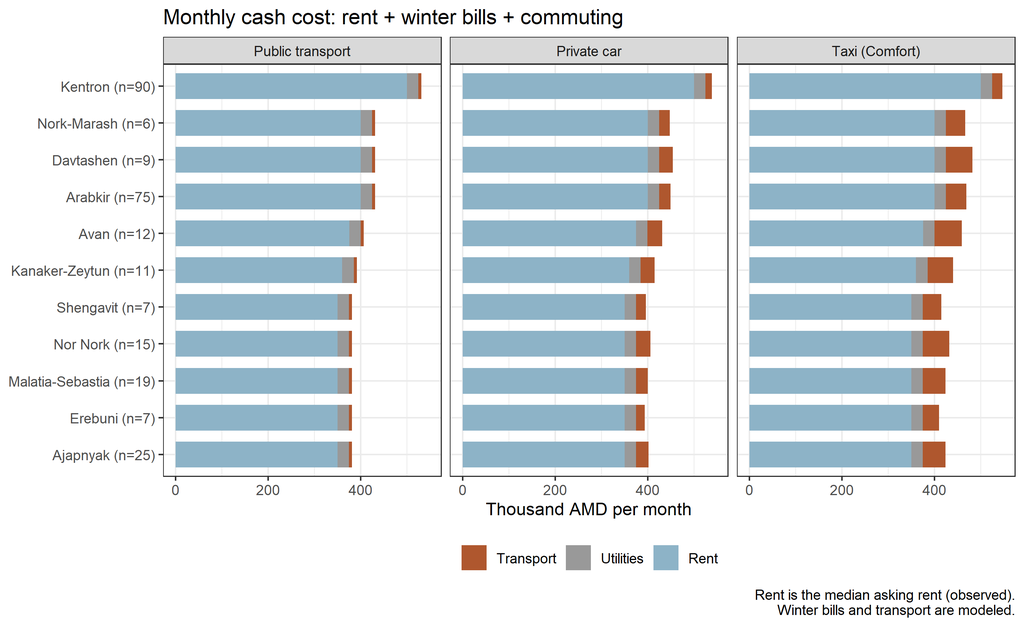

```r
# Monthly transport cost
# Bus: cheaper of single tickets or a 30-day pass
# Car: 60 AMD per km plus 10,000 AMD parking
# Taxi: one Comfort ride in the morning and one in the evening
bus_cost <- commuters * min(2 * days * rate("fare_single"), rate("fare_30day"))

budgets <- travel %>%
  mutate(car_cost = commuters * (km * days * 60 + 10000),
         taxi_cost = commuters * days * (taxi_fare(km / 2, road_in, "Comfort") +
                                         taxi_fare(km / 2, road_out, "Comfort")),
         transport = ifelse(mode == "Public transport", bus_cost,
                            ifelse(mode == "Private car", car_cost, taxi_cost)),
         hours = trip_minutes * days * commuters / 60,
         direct = rent + utilities + transport,
         with_time = direct + hours * time_value)

# Long table: one row per cost part
components <- rbind(
  data.frame(label = budgets$label, mode = budgets$mode,
             part = "Rent", amd = budgets$rent),
  data.frame(label = budgets$label, mode = budgets$mode,
             part = "Utilities", amd = utilities),
  data.frame(label = budgets$label, mode = budgets$mode,
             part = "Transport", amd = budgets$transport))

components$part <- factor(components$part,
                          levels = c("Transport", "Utilities", "Rent"))

ggplot(components, aes(x = factor(label, levels = label_order),
                       y = amd / 1000,
                       fill = part)) +
  geom_col(width = 0.7) +
  coord_flip() +
  facet_wrap(~factor(mode, levels = mode_order)) +
  scale_fill_manual(values = c("Rent" = "#8DB3C7",
                               "Utilities" = "grey60",
                               "Transport" = "#AF572E")) +
  labs(title = "Monthly cash cost: rent + winter bills + commuting",
       x = NULL,
       y = "Thousand AMD per month",
       fill = NULL,
       caption = paste("Rent is the median asking rent (observed).",
                       "Winter bills and transport are modeled.",
                       sep = "\n")) +
  theme(legend.position = "bottom")
```

**Answer.** Rent is the biggest part everywhere. Winter bills add 24,769 AMD in every district. A bus pass costs the same everywhere, but a daily taxi costs from 22,000 AMD (Kentron) to 59,400 AMD a month.

## How much saving is left after commuting?

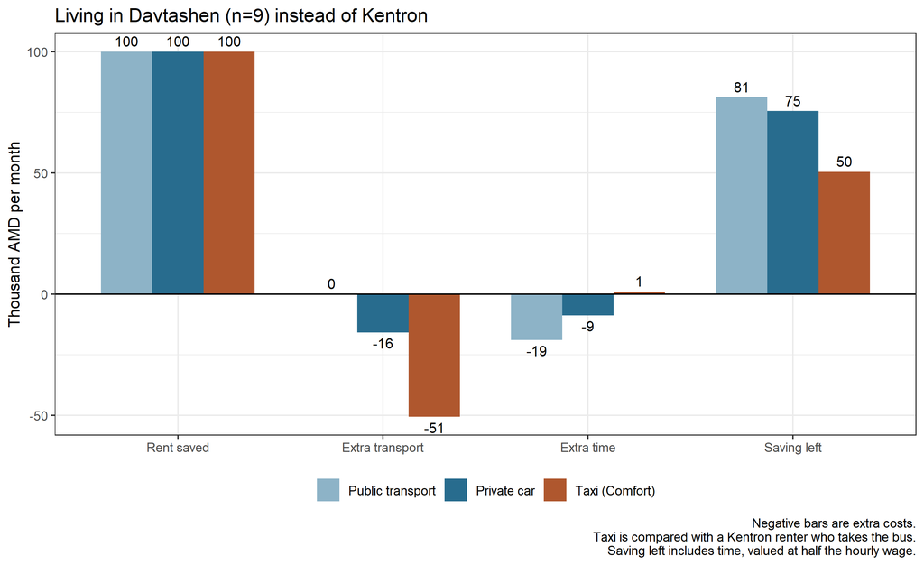

```r
# Compare every district with Kentron, for the same mode
central <- budgets %>%
  filter(district == "Kentron") %>%
  select(mode,
         central_direct = direct,
         central_hours = hours,
         central_total = with_time,
         central_transport = transport)

# A Kentron renter does not need a taxi:
# compare taxi users with a Kentron renter who takes the bus
taxi_central <- central %>%
  filter(mode == "Public transport") %>%
  mutate(mode = "Taxi (Comfort)")

central <- central %>%
  filter(mode != "Taxi (Comfort)") %>%
  rbind(taxi_central)

comparisons <- budgets %>%
  left_join(central, by = "mode") %>%
  mutate(saving = central_total - with_time,
         direct_difference = direct - central_direct,
         extra_hours = hours - central_hours)

noncentral <- comparisons %>%
  filter(district != "Kentron")

cheaper <- sum(noncentral$saving > 0)

# The district with the smallest saving left, over all three modes
focus_district <- noncentral$district[which.min(noncentral$saving)]

focus <- noncentral %>%
  filter(district == focus_district) %>%
  mutate(rent_saved = rent_kentron - rent,
         transport_added = transport - central_transport,
         time_added = extra_hours * time_value)

steps <- rbind(
  data.frame(mode = focus$mode, step = "Rent saved",
             amd = focus$rent_saved),
  data.frame(mode = focus$mode, step = "Extra transport",
             amd = -focus$transport_added),
  data.frame(mode = focus$mode, step = "Extra time",
             amd = -focus$time_added),
  data.frame(mode = focus$mode, step = "Saving left",
             amd = focus$saving))

steps$step <- factor(steps$step, levels = c("Rent saved", "Extra transport",
                                            "Extra time", "Saving left"))
steps$mode <- factor(steps$mode, levels = mode_order)

ggplot(steps, aes(x = step, y = amd / 1000, fill = mode)) +
  geom_col(position = "dodge", width = 0.75) +
  geom_hline(yintercept = 0) +
  geom_text(aes(label = round(amd / 1000),
                vjust = ifelse(amd < 0, 1.5, -0.5)),
            position = position_dodge(width = 0.75), size = 3.5) +
  scale_fill_manual(values = mode_colors, breaks = mode_order) +
  labs(title = paste("Living in", focus$label[1], "instead of Kentron"),
       x = NULL,
       y = "Thousand AMD per month",
       fill = NULL,
       caption = paste("Negative bars are extra costs.",
                       "Taxi is compared with a Kentron renter who takes the bus.",
                       "Saving left includes time, valued at half the hourly wage.",
                       sep = "\n")) +
  theme(legend.position = "bottom")
```

**Answer.** Davtashen (only 9 ads) keeps the smallest saving. Even with a daily taxi, compared with a Kentron renter who takes the bus, it still saves 50,432 AMD a month. 30 of the 30 district–mode examples stay cheaper than Kentron when time is valued at about 861 AMD an hour.

## Start or Comfort, and what if prices surge?

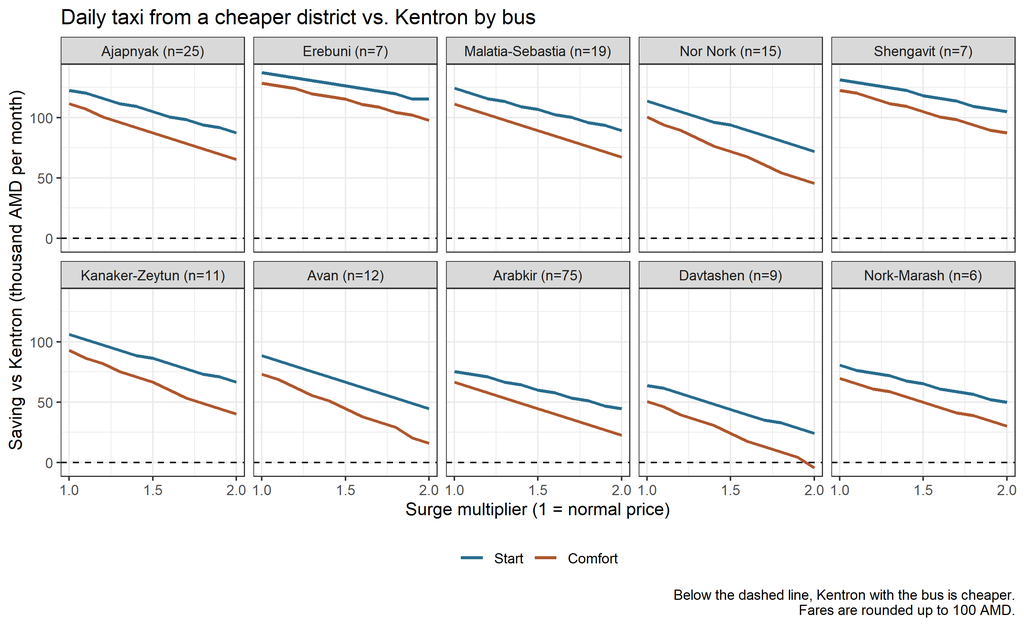

```r
# Monthly cost with a daily taxi, for both classes and surge from 1.0 to 2.0
surge_grid <- expand.grid(surge = seq(1, 2, by = 0.1),
                          class = c("Start", "Comfort"),
                          district = districts$district,
                          stringsAsFactors = FALSE) %>%
  left_join(districts, by = "district") %>%
  mutate(taxi_month = commuters * days *
           (taxi_fare(km / 2, road_in, class, surge) +
            taxi_fare(km / 2, road_out, class, surge)),
         taxi_hours = (road_in + road_out + 2 * taxi_wait) * days * commuters / 60,
         time_cost = taxi_hours * time_value,
         total = rent + utilities + taxi_month + time_cost)

# Saving compared with a Kentron renter who takes the bus
kentron_bus <- central$central_total[central$mode == "Public transport"]

surge_grid <- surge_grid %>%
  mutate(saving = kentron_bus - total) %>%
  filter(district != "Kentron")

# How much more Comfort costs than Start at normal prices
normal <- surge_grid %>% filter(surge == 1)
class_gap <- mean(normal$taxi_month[normal$class == "Comfort"] -
                  normal$taxi_month[normal$class == "Start"])

ggplot(surge_grid, aes(x = surge, y = saving / 1000, color = class)) +
  geom_line(linewidth = 1) +
  geom_hline(yintercept = 0, linetype = "dashed") +
  facet_wrap(~factor(label, levels = label_order), nrow = 2) +
  scale_x_continuous(breaks = c(1, 1.5, 2)) +
  scale_color_manual(values = c("Start" = "#286C8E", "Comfort" = "#AF572E"),
                     breaks = c("Start", "Comfort")) +
  labs(title = "Daily taxi from a cheaper district vs. Kentron by bus",
       x = "Surge multiplier (1 = normal price)",
       y = "Saving vs Kentron (thousand AMD per month)",
       color = NULL,
       caption = paste("Below the dashed line, Kentron with the bus is cheaper.",
                       "Fares are rounded up to 100 AMD.",
                       sep = "\n")) +
  theme(legend.position = "bottom")
```

**Answer.** Outside Kentron, Comfort costs about 11,660 AMD a month more than Start. Surge makes every saving smaller. At double prices the lowest saving is -4,568 AMD a month (Davtashen, Comfort). Only Davtashen crosses the dashed line, and only at a surge of 2 or more. Yandex’s rates are maximums, and a possible pickup fee is not included.

## When can the answer change?

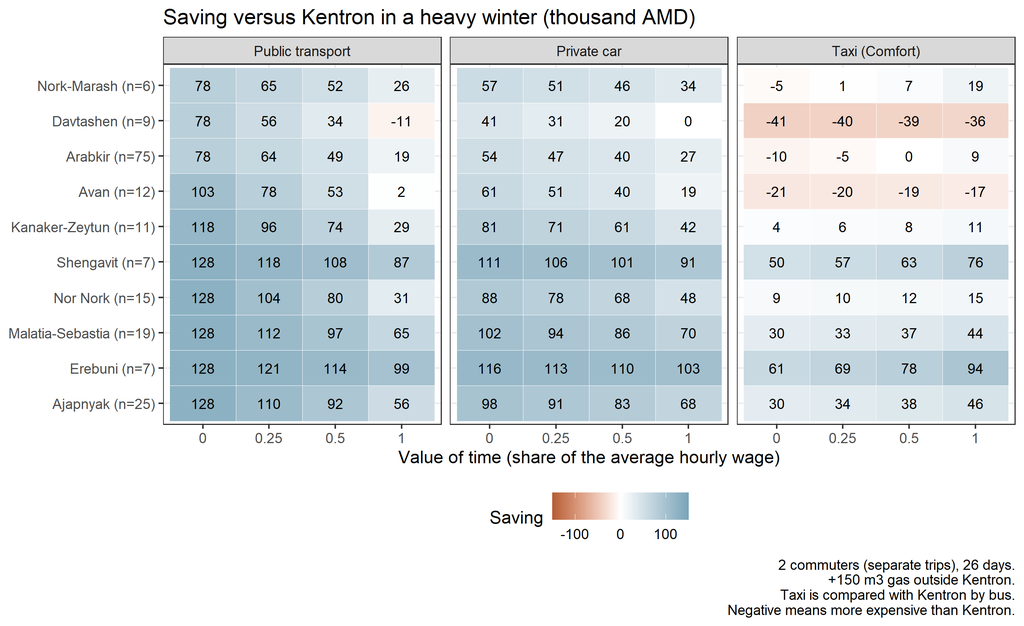

```r
# Every combination of heavier assumptions
grid <- expand.grid(workers = c(1, 2),
                    workdays = c(16, 22, 26),
                    fraction = c(0, 0.25, 0.5, 1),
                    extra_gas = c(0, 75, 150),
                    district = districts$district,
                    mode = c("Public transport", "Private car", "Taxi (Comfort)"),
                    stringsAsFactors = FALSE)

scenarios <- grid %>%
  left_join(travel, by = c("district", "mode")) %>%
  mutate(bus = workers * pmin(2 * workdays * rate("fare_single"),
                             rate("fare_30day")),
         car = workers * (km * workdays * 60 + 10000),
         cab = workers * workdays * (taxi_fare(km / 2, road_in, "Comfort") +
                                     taxi_fare(km / 2, road_out, "Comfort")),
         transport = ifelse(mode == "Public transport", bus,
                            ifelse(mode == "Private car", car, cab)),
         gas_extra = ifelse(district == "Kentron", 0,
                            extra_gas * rate("gas_per_1000m3") / 1000),
         time_cost = trip_minutes * workdays * workers / 60 * fraction * hourly,
         total = rent + utilities + gas_extra + transport + time_cost)

reference <- scenarios %>%
  filter(district == "Kentron") %>%
  select(mode, workers, workdays, fraction, extra_gas, reference = total)

# Taxi users are compared with a Kentron renter who takes the bus
taxi_reference <- reference %>%
  filter(mode == "Public transport") %>%
  mutate(mode = "Taxi (Comfort)")

reference <- reference %>%
  filter(mode != "Taxi (Comfort)") %>%
  rbind(taxi_reference)

scenarios <- scenarios %>%
  left_join(reference,
            by = c("mode", "workers", "workdays", "fraction", "extra_gas")) %>%
  mutate(saving = reference - total)

# Count the cases where a cheaper district costs more than Kentron
outside <- scenarios %>%
  filter(district != "Kentron")

reversals <- sum(outside$saving < 0)

# Show one heavy case: 2 commuters, 26 days, extra 150 m3 gas outside Kentron
stress_rows <- scenarios %>%
  filter(workers == 2, workdays == 26, extra_gas == 150, district != "Kentron")

ggplot(stress_rows, aes(x = factor(fraction),
                        y = factor(label, levels = label_order),
                        fill = saving / 1000)) +
  geom_tile(color = "white") +
  geom_text(aes(label = round(saving / 1000)), size = 3.2) +
  facet_wrap(~factor(mode, levels = mode_order)) +
  scale_fill_gradient2(low = "#B65D34", mid = "white", high = "#78A4B8",
                       midpoint = 0, limits = c(-150, 150),
                       breaks = c(-100, 0, 100)) +
  labs(title = "Saving versus Kentron in a heavy winter (thousand AMD)",
       x = "Value of time (share of the average hourly wage)",
       y = NULL,
       fill = "Saving",
       caption = paste("2 commuters (separate trips), 26 days.",
                       "+150 m3 gas outside Kentron.",
                       "Taxi is compared with Kentron by bus.",
                       "Negative means more expensive than Kentron.",
                       sep = "\n")) +
  theme(legend.position = "bottom")
```

**Answer.** Heavy commuting and extra heating can remove the saving. Of the 2160 combinations outside Kentron, 40 are more expensive than Kentron: 37 with a taxi, and 40 with two commuters. This count grows if traffic delays are larger than we assume and shrinks if they are smaller. These are what-if cases, not probabilities.

## When would the saving disappear?

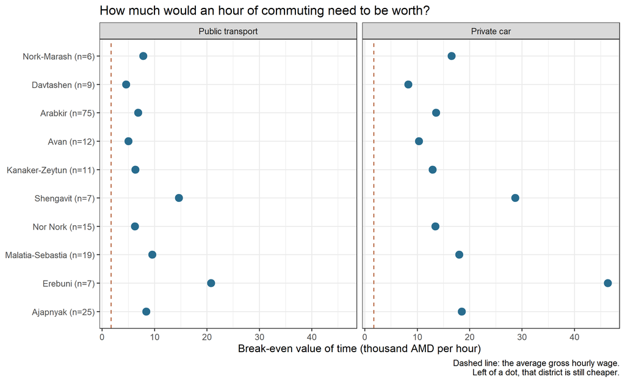

```r
# The value of one hour at which the saving becomes zero
thresholds <- noncentral %>%
  mutate(break_even = ifelse(direct_difference < 0 & extra_hours > 0,
                             -direct_difference / extra_hours, NA))

lowest_threshold <- min(thresholds$break_even, na.rm = TRUE)

# Taxi trips are faster than the bus from Kentron, so they have no break-even
no_break_even <- sum(is.na(thresholds$break_even))

points <- thresholds %>%
  filter(!is.na(break_even))

ggplot(points, aes(x = break_even / 1000,
                   y = factor(label, levels = label_order))) +
  geom_point(color = "#286C8E", size = 3.5) +
  geom_vline(xintercept = hourly / 1000, linetype = "dashed", color = "#AF572E") +
  facet_wrap(~factor(mode, levels = mode_order)) +
  labs(title = "How much would an hour of commuting need to be worth?",
       x = "Break-even value of time (thousand AMD per hour)",
       y = NULL,
       caption = paste("Dashed line: the average gross hourly wage.",
                       "Left of a dot, that district is still cheaper.",
                       sep = "\n"))
```

**Answer.** The lowest break-even value is about 4,555 AMD an hour, well above the average wage of 1,722 AMD an hour. For anyone whose commuting time is worth less than that, every cheaper district stays cheaper. The taxi has no dot: in all 10 taxi examples, the taxi is faster than the bus from Kentron, so valuing time only adds to the saving.

## Conclusion: where should a centre worker live?

In our baseline, 30 of the 30 district–mode examples are cheaper than Kentron, by bus, by car and by a daily Comfort taxi. The taxi leaves the smallest saving, because a fare grows with every extra kilometre and minute, while a bus pass costs the same everywhere: 50,432 AMD a month in Davtashen, compared with living in Kentron and taking the bus. At double taxi prices the smallest saving is -4,568 AMD a month: very heavy surge pricing can make Kentron the cheaper choice for a daily taxi user from Davtashen. In the stress test, Kentron wins in 40 heavy what-if cases, 40 of them with two commuters. In all our baseline examples, a renter who works in the centre saves by living farther out, but should still check a real offer against their own commute.

## Assumptions and limits

- **Sample:** one agency’s ads on 5 November 2026; asking prices, not signed leases. Some districts have fewer than 10 ads.
- **Household:** one commuter, 22 working days, a return trip each day: in at 08:45 and home at 18:30.
- **Winter bills:** 150 kWh day and 50 kWh night electricity, 100 m³ gas, 8 m³ water, the same in every district. Heating is counted once, as gas.
- **Travel:** road distances and empty-road times from OSRM (OpenStreetMap). Bus time is 12 km/h plus 15 minutes of walking and waiting per trip.
- **Traffic:** road time = empty-road time × (1 + 0.13 × (Yandex score − 2)). Yandex does not publish how its score turns into minutes. We chose 0.13 so that the evening peak (score 7.8) gives about +75%. Yerevan’s mayor said in October 2026 that rush-hour bus trips can take “as much as” 70–80% longer than in the morning; we read “the morning” as empty roads (score 2). Because that figure is a maximum, 0.13 probably overstates delays, which works against the far districts. Numbeo’s 48 self-reported car commutes (about 27 km/h) are roughly consistent with it. The scores were read by hand from Yandex’s February 2020 weekday chart. They are a city-wide average, so every district gets the same percentage stretch.
- **Bus time** is not traffic-adjusted: its 12 km/h is assumed to include traffic. Car cost per km ignores extra fuel used in traffic.
- **Taxi:** Yandex Comfort rates from the official Yerevan fare page on 24 November 2026. These are maximum rates; surge and any pickup fee are not included. Surge is tested separately. Taxi users are compared with a Kentron renter who takes the bus, since a Kentron renter does not need a taxi. Waiting for the car (3 minutes) costs time, not money.
- **Time:** valued at half of the 2025 average gross wage divided by 176 hours. A value of zero gives the cash-only result.
- **District budgets** combine district medians; they are examples, not real household bills.
- **No p-values:** the ads are not a random sample, and the scenarios are not independent households.

## References

- WSE.AM. [Rental catalogue and public property API](https://wse.am/en/apartments-for-rent-yerevan). Snapshot 5 November 2026.
- WSE.AM. [Public property API access rules](https://wse.am/robots.txt). Accessed 5 November 2026.
- Yerevan Municipality. [Unified public transport ticket comparison](https://transport.yerevan.am/). Accessed 5 November 2026.
- Electric Networks of Armenia. [Household electricity tariffs](https://www.ena.am/Info.aspx?id=11&lang=2). Accessed 5 November 2026.
- Public Services Regulatory Commission. [Natural gas tariff decision](https://www.psrc.am/contents/newsPress/gas-tariff-22), 1 March 2022, and [2026 no-change notice](https://psrc.am/contents/page/posts/natural-gas-tariffs-for-residents-will-stay-unchanged). Accessed 5 November 2026.
- Veolia Djur. [2026 drinking water tariff](https://www.veolia.am/en/news/2026-drinking-water-tariff-consumers-will-not-increase) and [metering FAQ](https://www.veolia.am/en/consumers/frequently-asked-questions). Accessed 5 November 2026.
- Armstat. [Average monthly nominal wages, SDG 8.5.1](https://sdg.armstat.am/8-5-1-a-iframe/). Accessed 5 November 2026.
- Project OSRM. [OSRM HTTP API](https://project-osrm.org/docs/v26.5.0/http), with [OpenStreetMap data](https://www.openstreetmap.org/copyright). Accessed 5 November 2026.
- Yandex Go. [Ride fares in Yerevan: Comfort](https://taxi.yandex.com/en_am/yerevan/tariff/business/) and [Start](https://taxi.yandex.com/en_am/yerevan/tariff/start/). Accessed 24 November 2026.
- Mediamax. [Yandex.Traffic and the coronavirus in Yerevan](https://mediamax.am/ru/news/yerevan/38359/), 1 July 2020 (weekday traffic chart, February 2020). Accessed 24 November 2026.
- PAN.am. [Yerevan mayor calls for measures to ease traffic jams](https://www.pan.am/en/626214), 12 October 2026. Accessed 24 November 2026.
- Numbeo. [Traffic in Yerevan](https://www.numbeo.com/traffic/in/Yerevan). Accessed 24 November 2026.
- Habet Madoyan. [DS116 lecture materials](https://github.com/ReneViva/DS116-Data-Visualization). American University of Armenia.
- [ggplot2](https://ggplot2.tidyverse.org/reference/), [dplyr](https://dplyr.tidyverse.org/reference/) and [knitr](https://yihui.org/knitr/) documentation.